# Support Vector Machine - Capstone Project

Author

Gopi Shankar Reddy Mallu, Kavya Reddy Maale, Satya Nageswara Dinesh Donkada, Vamsi Krishna Kalla

Published

February 26, 2024

## Introduction

### Support Vector Machines.

Support Vector Machines (SVMs) are a type of supervised learning algorithm that can be used for classification or regression tasks. The main idea behind SVMs is to find a hyperplane that maximally separates the different classes in the training data. This is done by finding the hyperplane that has the largest margin, which is defined as the distance between the hyperplane and the closest data points from each class. Once the hyperplane is determined, new data can be classified by determining on which side of the hyperplane it falls. SVMs are particularly useful when the data has many features, and/or when there is a clear margin of separation in the data.

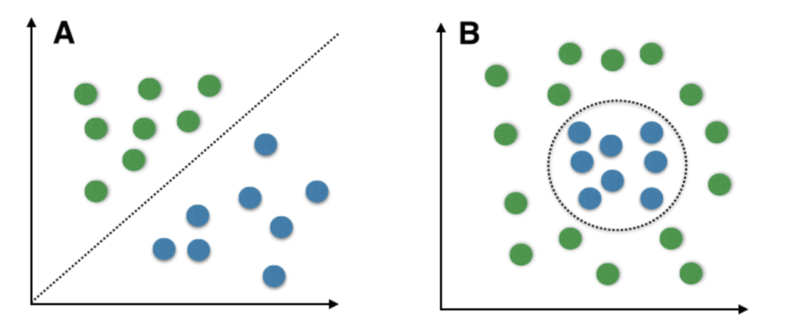

Hyperplanes are decision boundaries that help classify the data points. Data points falling on either side of the hyperplane can be attributed to different classes. Also, the dimension of the hyperplane depends upon the number of features. If the number of input features is 2, then the hyperplane is just a line. If the number of input features is 3, then the hyperplane becomes a two-dimensional plane. It becomes difficult to imagine when the number of features exceeds 3.

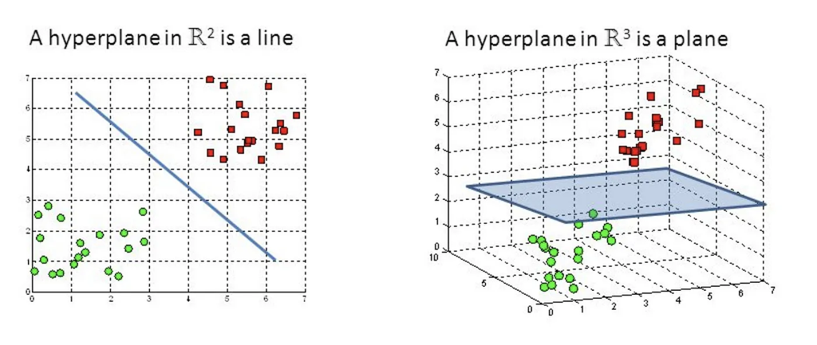

### **Mathematical Intuition of Support Vector Machine**

Consider a binary classification task where there are two classes, denoted by the labels +1 and -1. The input feature vectors (X) and the matching class labels (Y) comprise our training dataset.

Equation for hyperplane can be written as:

$w^Tx+b=0$

The vector W represents the normal vector to the hyperplane. i.e the direction perpendicular to the hyperplane. The parameter **b** in the equation represents the offset or distance of the hyperplane from the origin along the normal vector **w**.

$d_i = \frac{w^Tx_i + b}{\|w\|}$

where ||w|| represents the Euclidean norm of the weight vector w. Euclidean norm of the normal vector W

### kernel function in SVM

SVM kernel is a function that takes low-dimensional input space and transforms it into higher-dimensional space, ie it converts nonseparable problems to separable problems. It is mostly useful in non-linear separation problems. Simply put the kernel, does some extremely complex data transformations and then finds out the process to separate the data based on the labels or outputs defined.

$Linear : K(w,b)=w^Tx+b$

## Literature Review

Support Vector Machines (SVM) have emerged as a potent tool in the realm of supervised learning, offering a robust mathematical framework for both classification and regression tasks. With a foundation rooted in principles such as structural risk minimization and kernel functions (Jakkula, 2006), SVM has demonstrated exceptional generalization capabilities, adeptly handling non-linear decision boundaries through kernel tricks (Jun, 2021; Deris, 2011). Despite challenges like computational cost and scalability (Bhavsar, 2012), the evolution of SVM has led to significant contributions in diverse fields, including pattern recognition, computer vision (Kecman, 2005), and even agriculture, where it aids in optimizing crop yield and disease identification (Kumar et al., 2017). The ongoing advancements in SVM research are geared towards refining algorithms and broadening their application spectrum, especially in the context of burgeoning data volumes (Yue, 2003).

In the financial and healthcare sectors, SVM has proven its efficacy in various applications. It has been utilized to construct reliable stock market prediction models by analyzing financial indices like Earnings Per Share (EPS) and Net Profit Growth Rate (NPGR) (Han, 2007). In healthcare, SVM has been instrumental in developing advanced diagnostic tools, such as the optimized SVM model for early dementia prediction (Javeed et al., 2023) and the multi-disease prediction model using an improved SVM-radial bias kernel approach (Harimoorthy & Thangavelu, 2021). These innovations underscore the potential of machine learning in revolutionizing healthcare by facilitating early diagnosis and personalized treatment plans.

SVM’s application extends to domains like online retail and network security, where it addresses complex challenges with remarkable efficiency. In online marketplaces, SVM combined with Particle Swarm Optimization has enhanced the accuracy of text classification for customer reviews (Sahara et al., 2023), providing valuable insights for sellers. In the realm of network security, innovative approaches such as combining SVM with naïve Bayes feature embedding have been proposed for intrusion detection, achieving high accuracy rates in identifying network threats (Computers & Security, 2021). Moreover, the development of hybrid methods for attack detection, which integrate SVM features with evolutionary algorithms and artificial neural networks, has shown significant promise in reducing dimensionality and training time while maintaining high detection accuracy (Computer Networks, 2020).

Machine learning techniques, particularly SVM, are revolutionizing various fields by addressing complex challenges with precision and efficiency. In healthcare, SVM has been applied to electronic health records for cancer classification, achieving high accuracy rates in identifying different types of malignancies (IEEE Xplore, 2021). Furthermore, SVM’s versatility is evident in its application across domains such as finance, where it has been used to assess credit risk for small and medium enterprises in supply chain finance (Zhang, Hu, & Zhang, 2015), and in cloud-based services, where it ensures data confidentiality and decision verifiability in health monitoring systems (Liang et al., 2021). These advancements highlight the transformative potential of machine learning techniques in enhancing diagnostic accuracy, optimizing financial assessments, and ensuring secure cloud-based services.

## Dataset

Customer retention is a critical aspect for banks to ensure the sustainability of their operations. ABC Multinational Bank, in particular, places a strong emphasis on retaining its account holders. The primary objective of this analysis is to examine the customer data of the bank’s account holders to predict and prevent customer churn effectively.

The dataset under consideration contains information about account holders at ABC Multinational Bank, with the ultimate goal of predicting customer churn. The dataset comprises the following columns:

| Column Name | Description |
| --- | --- |
| `customer_id` | A unique identifier for each customer, not used in the analysis. |
| `credit_score` | A numerical representation of the customer’s creditworthiness. |
| `country` | The country in which the customer resides. |
| `gender` | The gender of the customer (e.g., male, female). |
| `age` | The age of the customer in years. |
| `tenure` | The number of years the customer has been with the bank. |
| `balance` | The current balance in the customer’s account. |
| `products_number` | The number of products the customer has with the bank. |
| `credit_card` | Indicates whether the customer has a credit card with the bank. |
| `active_member` | Indicates whether the customer is an active member. |
| `estimated_salary` | The estimated annual salary of the customer. |
| `churn` | The target variable, indicating customer churn (1 for churned, 0 for not churned). |

```r
library(tidyverse)
library(dplyr)
library(ggplot2)
#install.packages("corrplot")
library(corrplot)
```

```r
df <- read.csv("dataset/train.csv")
```

```r
head(df)
```

```
  id CustomerId        Surname CreditScore Geography Gender Age Tenure  Balance
1  0   15674932 Okwudilichukwu         668    France   Male  33      3      0.0
2  1   15749177  Okwudiliolisa         627    France   Male  33      1      0.0
3  2   15694510          Hsueh         678    France   Male  40     10      0.0
4  3   15741417            Kao         581    France   Male  34      2 148882.5
5  4   15766172      Chiemenam         716     Spain   Male  33      5      0.0
6  5   15771669       Genovese         588   Germany   Male  36      4 131778.6
  NumOfProducts HasCrCard IsActiveMember EstimatedSalary Exited
1             2         1              0       181449.97      0
2             2         1              1        49503.50      0
3             2         1              0       184866.69      0
4             1         1              1        84560.88      0
5             2         1              1        15068.83      0
6             1         1              0       136024.31      1
```

```r
summary(select(df, CreditScore, Age, Tenure, Balance, NumOfProducts, EstimatedSalary))
```

```
  CreditScore         Age            Tenure         Balance
 Min.   :350.0   Min.   :18.00   Min.   : 0.00   Min.   :     0
 1st Qu.:597.0   1st Qu.:32.00   1st Qu.: 3.00   1st Qu.:     0
 Median :659.0   Median :37.00   Median : 5.00   Median :     0
 Mean   :656.5   Mean   :38.13   Mean   : 5.02   Mean   : 55478
 3rd Qu.:710.0   3rd Qu.:42.00   3rd Qu.: 7.00   3rd Qu.:119940
 Max.   :850.0   Max.   :92.00   Max.   :10.00   Max.   :250898
 NumOfProducts   EstimatedSalary
 Min.   :1.000   Min.   :    11.58
 1st Qu.:1.000   1st Qu.: 74637.57
 Median :2.000   Median :117948.00
 Mean   :1.554   Mean   :112574.82
 3rd Qu.:2.000   3rd Qu.:155152.47
 Max.   :4.000   Max.   :199992.48
```

```r
sapply(df[,c('Geography', 'Gender', 'HasCrCard', 'IsActiveMember', 'Exited')], function(x) length(unique(x)))
```

```
     Geography         Gender      HasCrCard IsActiveMember         Exited
             3              2              2              2              2
```

```r
colSums(is.na(df))
```

```
             id      CustomerId         Surname     CreditScore       Geography
              0               0               0               0               0
         Gender             Age          Tenure         Balance   NumOfProducts
              0               0               0               0               0
      HasCrCard  IsActiveMember EstimatedSalary          Exited
              0               0               0               0
```

```r
table(df$Exited)
```

```
     0      1
130113  34921
```

```r
# Relationship between Geography and Exited
table(df$Geography, df$Exited)
```

```
              0     1
  France  78643 15572
  Germany 21492 13114
  Spain   29978  6235
```

```r
aggregate(df$CreditScore, by = list(df$Gender), FUN = mean)
```

```
  Group.1        x
1  Female 656.2437
2    Male 656.6169
```

```r
# Correlation between numerical variables
cor(select(df, CreditScore, Age, Tenure, Balance, NumOfProducts, EstimatedSalary))
```

```
                  CreditScore          Age        Tenure      Balance
CreditScore      1.0000000000 -0.008918146  0.0009424799  0.006973053
Age             -0.0089181458  1.000000000 -0.0108303451  0.064318287
Tenure           0.0009424799 -0.010830345  1.0000000000 -0.009481186
Balance          0.0069730535  0.064318287 -0.0094811862  1.000000000
NumOfProducts    0.0113608082 -0.102194912  0.0073348275 -0.361032521
EstimatedSalary -0.0018203035 -0.005398663  0.0009705869  0.008586201
                NumOfProducts EstimatedSalary
CreditScore       0.011360808   -0.0018203035
Age              -0.102194912   -0.0053986634
Tenure            0.007334828    0.0009705869
Balance          -0.361032521    0.0085862012
NumOfProducts     1.000000000   -0.0042850891
EstimatedSalary  -0.004285089    1.0000000000
```

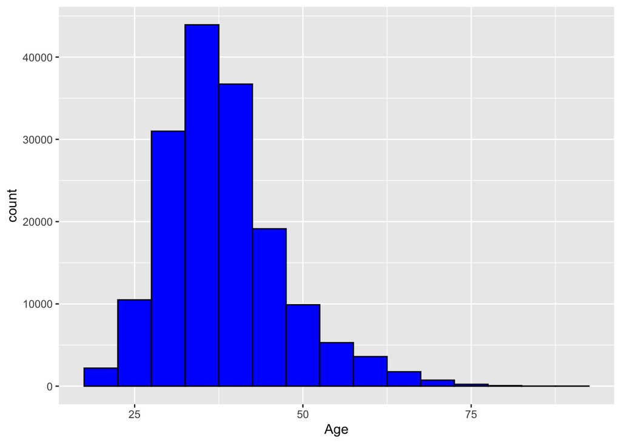

```r
# Histogram of Age
ggplot(df, aes(x = Age)) + geom_histogram(binwidth = 5, fill = "blue", color = "black")
```

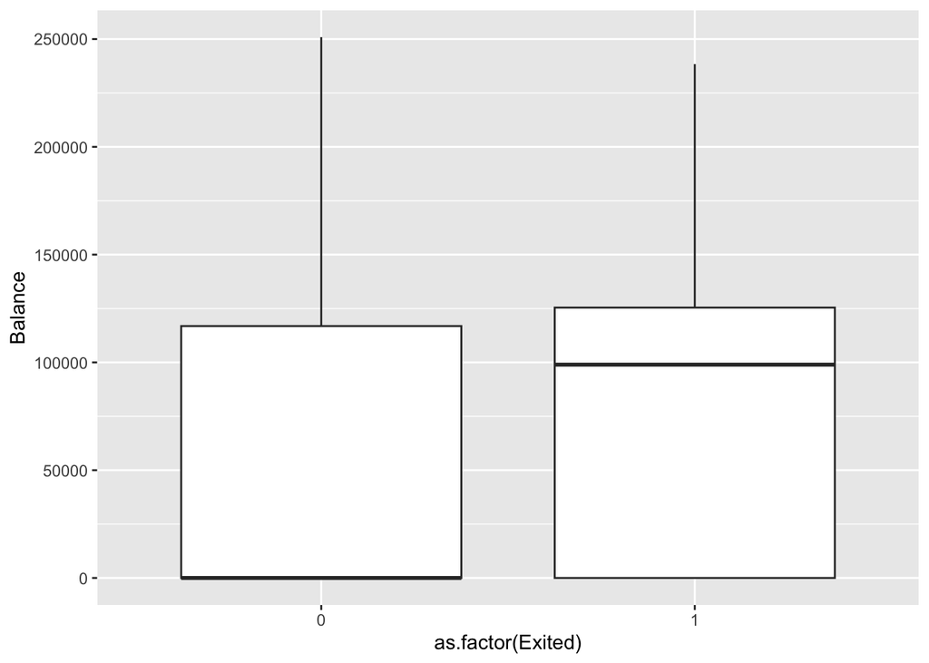

```r
ggplot(df, aes(x = as.factor(Exited), y = Balance)) + geom_boxplot()
```

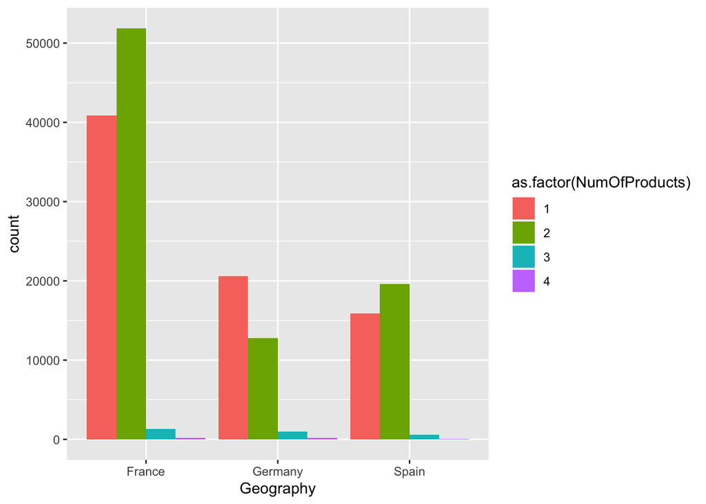

```r
ggplot(df, aes(x = Geography, fill = as.factor(NumOfProducts))) + geom_bar(position = "dodge")
```

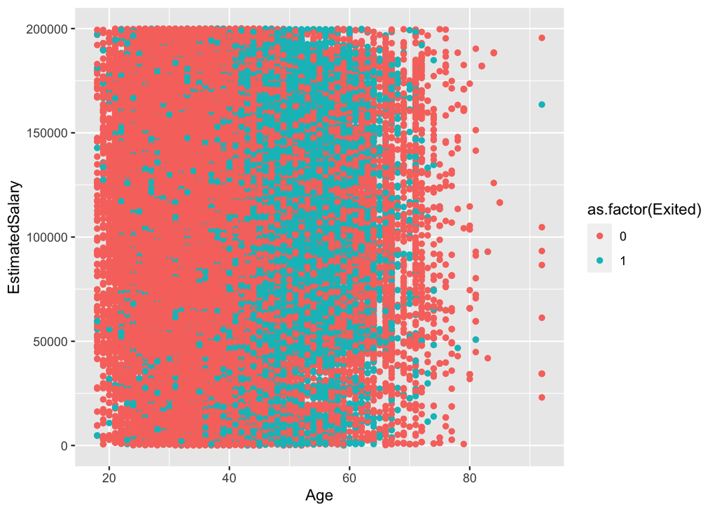

```r
# Scatter plot of Age vs EstimatedSalary colored by Exited
ggplot(df, aes(x = Age, y = EstimatedSalary, color = as.factor(Exited))) + geom_point()
```

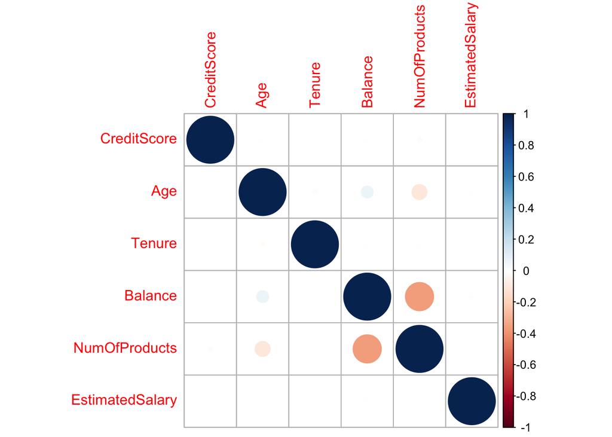

```r
corr_matrix <- cor(select(df, CreditScore, Age, Tenure, Balance, NumOfProducts, EstimatedSalary))
corrplot(corr_matrix, method = "circle")
```

## References

1. Rangala, M. (n.d.). *Bank Churn Dataset*. Www.kaggle.com. Retrieved February 20, 2024, from https://www.kaggle.com/datasets/rangalamahesh/bank-churn
2. Jakkula, V. (2006). Tutorial on support vector machine (svm). *School of EECS, Washington State University*, *37*(2.5), 3.
3. Kecman, V. (2005). Support vector machines-an introduction. In Support vector machines theory and applications (pp. 1-47). Berlin, Heidelberg: Springer Berlin Heidelberg
4. Yue, S., Li, P., & Hao, P. (2003). SVM classification: Its contents and challenges. Applied Mathematics-A Journal of Chinese Universities, 18, 332-342.
5. Jun, Z. (2021). The development and application of support vector machine. In *Journal of Physics: Conference Series* (Vol. 1748, No. 5, p. 052006). IOP Publishing.
6. Bhavsar, H., & Panchal, M. H. (2012). A review on support vector machine for data classification. International Journal of Advanced Research in Computer Engineering & Technology (IJARCET), 1(10), 185-189.
7. Deris, A. M., Zain, A. M., & Sallehuddin, R. (2011). Overview of support vector machine in modeling machining performances. *Procedia Engineering*, *24*, 308-312.
8. Han, Shuo. “Using SVM with Financial Statement Analysis for Prediction of Stocks.” *Communications of the IIMA Communications of the IIMA*, vol. 7, 2007, scholarworks.lib.csusb.edu/cgi/viewcontent.cgi?article=1059&context=ciima.
9. Ahmadi, Muhammad Iqbal, et al. “SENTIMENT ANALYSIS ONLINE SHOP on the PLAY STORE USING METHOD SUPPORT VECTOR MACHINE (SVM).” *Seminar Nasional Informatika (SEMNASIF)*, vol. 1, no. 1, 15 Dec. 2020, pp. 196–203, jurnal.upnyk.ac.id/index.php/semnasif/article/view/4101. Accessed 13 Feb. 2024.
10. Razzaghi, Talayeh, et al. “Multilevel Weighted Support Vector Machine for Classification on Healthcare Data with Missing Values.” *PLOS ONE*, vol. 11, no. 5, 19 May 2016, p. e0155119, https://doi.org/10.1371/journal.pone.0155119.
11. Öz, Ersoy, and Hüseyin Kaya. “Support Vector Machines for Quality Control of DNA Sequencing.” *Journal of Inequalities and Applications*, vol. 2013, no. 1, 4 Mar. 2013, https://doi.org/10.1186/1029-242x-2013-85. Accessed 15 June 2021.
12. “Support Vector Machine for Network Intrusion and Cyber-Attack Detection | IEEE Conference Publication | IEEE Xplore.” *Ieeexplore.ieee.org*, ieeexplore.ieee.org/abstract/document/8233268. Accessed 13 Feb 2024.
13. Kumar, Sachin, et al. “Precision Sugarcane Monitoring Using SVM Classifier.” *Procedia Computer Science*, vol. 122, 2017, pp. 881–887, https://doi.org/10.1016/j.procs.2017.11.450. Accessed 25 July 2019.
14. Javeed, A. et al. (2023) Early prediction of dementia using feature Extraction Battery (FEB) and optimized support vector machine (SVM) for Classification, MDPI. Available at: https://www.mdpi.com/2227-9059/11/2/439 (Accessed: 22 January 2024).
15. Nawal, Y., Oussalah, M., Fergani, B., & Fleury, A. (2022). New incremental SVM algorithms for human activity recognition in smart homes. Journal of Ambient Intelligence and Humanized Computing. https://doi.org/10.1007/s12652-022-03798-w
16. Zhang, L., Hu, H., & Zhang, D. (2015). A credit risk assessment model based on SVM for small and medium enterprises in supply chain finance. *Financial Innovation*, *1*(1). https://doi.org/10.1186/s40854-015-0014-5
17. Harimoorthy, K., Thangavelu, M. RETRACTED ARTICLE: Multi-disease prediction model using improved SVM-radial bias technique in healthcare monitoring system. *J Ambient Intell Human Comput* **12**, 3715–3723 (2021). https://doi.org/10.1007/s12652-019-01652-0
18. J. Liang, Z. Qin, L. Xue, X. Lin and X. Shen, “Verifiable and Secure SVM Classification for Cloud-Based Health Monitoring Services,” in IEEE Internet of Things Journal, vol. 8, no. 23, pp. 17029-17042, 1 Dec.1, 2021, doi: 10.1109/JIOT.2021.3075540.
19. G. N. Ahmad, H. Fatima, S. Ullah, A. Salah Saidi and Imdadullah, “Efficient Medical Diagnosis of Human Heart Diseases Using Machine Learning Techniques With and Without GridSearchCV,” in IEEE Access, vol. 10, pp. 80151-80173, 2022, doi: 10.1109/ACCESS.2022.3165792.
20. Sahara, S., Annida Purnamawati, Sulaeman Hadi Sukmana, Mely Mailasari, Erma Delima Sikumbang, & Puji, E. (2023). PSO optimization for analysis of online marketplace products on the SVM method. *AIP Conference Proceedings*. https://doi.org/10.1063/5.0129404
21. “Prediction of Consumer Purchasing in a Grocery Store Using Machine Learning Techniques.” *Ieeexplore.ieee.org*, ieeexplore.ieee.org/document/7941935.
22. Barakat, Nahla, et al. “Intelligible Support Vector Machines for Diagnosis of Diabetes Mellitus.” *IEEE Transactions on Information Technology in Biomedicine*, vol. 14, no. 4, July 2010, pp. 1114–1120, https://doi.org/10.1109/titb.2009.2039485.
23. “Applying Support Vector Machine to Electronic Health Records for Cancer Classification | IEEE Conference Publication | IEEE Xplore.” *Ieeexplore.ieee.org*, ieeexplore.ieee.org/abstract/document/8732906.
24. “An Effective Intrusion Detection Approach Using SVM with Naïve Bayes Feature Embedding.” *Computers & Security*, vol. 103, 1 Apr. 2021, p. 102158, www.sciencedirect.com/science/article/pii/S0167404820304314, https://doi.org/10.1016/j.cose.2020.102158.
25. Hosseini, Soodeh, and Behnam Mohammad Hasani Zade. “New Hybrid Method for Attack Detection Using Combination of Evolutionary Algorithms, SVM, and ANN.” *Computer Networks*, vol. 173, May 2020, p. 107168, https://doi.org/10.1016/j.comnet.2020.107168.